```python
# mounting the drive
from google.colab import drive
drive.mount('/content/drive')
```

# Assignment 8

Gene expression data is highly dynamic and temporal. In this assignment, you will compare two deep learning approaches—an LSTM model and an Attention-based model—to classify gene expression patterns. You will use three synthetic gene expression datasets, each with a different sequence length (100, 200, and 300 time steps). Additionally, you will perform grid search hyperparameter tuning to find the best model configurations for each architecture.

## Dataset

You will work with three datasets:  
● gene_expression_data_100.csv: 100 time steps  
● gene_expression_data_200.csv: 200 time steps  
● gene_expression_data_300.csv: 300 time steps  
Each dataset contains 1,000 samples with 10 gene features per time step. The outcome (binary) indicates a specific gene expression pattern that you need to classify.

```python
import pandas as pd
import numpy as np
from sklearn.model_selection import train_test_split
import tensorflow as tf
from tensorflow.keras.models import Sequential
from tensorflow.keras.layers import LSTM, Dense, Dropout, MultiHeadAttention, LayerNormalization, Add, GlobalAveragePooling1D
from tensorflow.keras.optimizers import Adam
import matplotlib.pyplot as plt

data_100 = pd.read_csv("/content/drive/MyDrive/QBIO465/gene_expression_data_100.csv")
data_200 = pd.read_csv("/content/drive/MyDrive/QBIO465/gene_expression_data_200.csv")
data_300 = pd.read_csv("/content/drive/MyDrive/QBIO465/gene_expression_data_300.csv")
```

# Q1: Data Preparation [1 pts]

● Load each CSV file and reshape the data to match the input requirements of your models, i.e., a 3D array of shape (num_samples, num_time_steps, num_genes).  
● Split the data into training and testing sets (80/20 split).

```python
def prepare_data(data):
  y = data['Outcome'].values.astype(np.float32)
  x = data.drop('Outcome', axis=1).values.astype(np.float32)
  num_samples = x.shape[0]
  num_genes = 10
  num_time_steps = x.shape[1] // num_genes
  x = x.reshape(num_samples, num_time_steps, num_genes)
  return train_test_split(x, y, test_size=0.2, random_state=42)

# loading the datasets with our fxn
x_train_100, x_test_100, y_train_100, y_test_100 = prepare_data(data_100)
x_train_200, x_test_200, y_train_200, y_test_200 = prepare_data(data_200)
x_train_300, x_test_300, y_train_300, y_test_300 = prepare_data(data_300)
```

# Q2: LSTM Model Implementation [1 pts]

● Build an LSTM model that accepts input of shape (num_time_steps, num_genes) and outputs a binary classification.  
● Develop a grid search procedure to tune key hyperparameters (e.g., number of LSTM units, dropout rate, batch size, learning rate, etc.). You may choose which hyperparameters to tune. To reduce computational cost, perform the hyperparameter search using only the gene_expression_data_100.csv dataset.  
● Report the best hyperparameter configuration for the model and discuss the impact of hyperparameter tuning via grid search on the model’s performance.

```python
def lstm_model(units=64, dropout_rate=0.3, learning_rate=0.001, sequence_length=None, feature_dim=None):
  model = Sequential([
      tf.keras.Input(shape=(x_train_100.shape[1], x_train_100.shape[2])),
      LSTM(units),
      Dropout(dropout_rate),
      Dense(1, activation='sigmoid')
      ])
  model.compile(optimizer=Adam(learning_rate=learning_rate),
                loss='binary_crossentropy',
                metrics=['accuracy'])
  return model

# doing grid search
lstm_hyperparameters = {
    'units': [32, 64],
    'dropout_rate': [0.2, 0.3],
    'learning_rate': [0.001, 0.0005],
    'batch_size': [32, 64]
}

best_val_acc = 0
best_lstm_model = None
best_lstm_parameters = {}

for units in lstm_hyperparameters['units']:
  for dropout in lstm_hyperparameters['dropout_rate']:
    for lr in lstm_hyperparameters['learning_rate']:
      for batch in lstm_hyperparameters['batch_size']:
        model = lstm_model(units=units, dropout_rate=dropout, learning_rate=lr)
        history = model.fit(x_train_100, y_train_100,
                            validation_data=(x_test_100, y_test_100),
                            epochs=10, batch_size=batch, verbose=0)
        val_acc = history.history['val_accuracy'][-1]
        if val_acc > best_val_acc:
          best_val_acc = val_acc
          best_lstm_model = model
          best_lstm_parameters = {'units':units, 'dropout_rate': dropout,
                                  'learning_rate': lr, 'batch_size': batch}

print("Best LSTM Parameters: ", best_lstm_parameters)
print("Best Validation Accuracy: ", best_val_acc)
```

```
Best LSTM Parameters:  {'units': 64, 'dropout_rate': 0.3, 'learning_rate': 0.001, 'batch_size': 32}
Best Validation Accuracy:  0.6600000262260437
```

# Q3: Attention-Based Model Implementation [2 pts]

● Build an attention-based model using TensorFlow’s MultiHeadAttention layer, incorporating a residual connection, layer normalization, and a feed-forward network. The model should accept input of shape (num_time_steps, num_genes) and output a binary classification.  
● Develop a grid search procedure to tune key hyperparameters (e.g., number of attention heads, feed-forward dimension, dropout rate, batch size, learning rate, etc.). You may choose which hyperparameters to include. To reduce computational cost, perform the hyperparameter search using only the gene_expression_data_100.csv dataset.  
● Report the best hyperparameter configuration for the model and discuss the impact of hyperparameter tuning via grid search on the model’s performance.

```python
def attention_model(num_heads=2, ff_dim=64, dropout_rate=0.3, learning_rate=0.001, sequence_length=100, feature_dim=10):
  inputs = tf.keras.Input(shape=(sequence_length, feature_dim))
  attn_output = MultiHeadAttention(num_heads=num_heads, key_dim=feature_dim)(inputs, inputs)
  attn_output = Dropout(dropout_rate)(attn_output)
  out1 = Add() ([inputs, attn_output])
  out1 = LayerNormalization()(out1)

  # ffn
  ffn = tf.keras.Sequential([Dense(ff_dim, activation='relu'),
                             Dense(x_train_100.shape[2])])

  ffn_output= ffn(out1)
  ffn_output = Dropout(dropout_rate)(ffn_output)
  out2 = Add()([out1, ffn_output])
  out2 = LayerNormalization()(out2)

  x = GlobalAveragePooling1D()(out2)
  outputs = Dense(1, activation='sigmoid')(x)

  model = tf.keras.Model(inputs=inputs, outputs=outputs)
  model.compile(optimizer=Adam(learning_rate=learning_rate),
                loss='binary_crossentropy',
                metrics=['accuracy'])
  return model
```

```python
# grid search
attention_hyperparameters = {
    'num_heads': [2, 4],
    'ff_dim': [32, 64],
    'dropout_rate': [0.2, 0.3],
    'learning_rate': [0.001, 0.0005],
    'batch_size': [32, 64]
}
best_attn_val_acc = 0
best_attn_model = None
best_attn_parameters = {}

for heads in attention_hyperparameters['num_heads']:
  for ff_dim in attention_hyperparameters['ff_dim']:
    for dropout in attention_hyperparameters['dropout_rate']:
      for lr in attention_hyperparameters['learning_rate']:
        for batch in attention_hyperparameters['batch_size']:
          model = attention_model(num_heads=heads, ff_dim=ff_dim, dropout_rate=dropout, learning_rate=lr, sequence_length=100, feature_dim=10)
          history = model.fit(x_train_100, y_train_100,
                              validation_data=(x_test_100, y_test_100),
                              epochs=10, batch_size=batch, verbose=0)
          val_acc = history.history['val_accuracy'][-1]
          if val_acc > best_attn_val_acc:
            best_attn_val_acc = val_acc
            best_attn_model = model
            best_attn_parameters = {
                'num_heads': heads,
                'ff_dim': ff_dim,
                'dropout_rate': dropout,
                'learning_rate': lr,
                'batch_size': batch
                }
print("Best Attention Parameters: ", best_attn_parameters)
print("Best Validation Accuracy: ", best_attn_val_acc)
```

```
Best Attention Parameters:  {'num_heads': 2, 'ff_dim': 32, 'dropout_rate': 0.2, 'learning_rate': 0.0005, 'batch_size': 64}
Best Validation Accuracy:  0.6600000262260437
```

# Q4: Training and Evaluation [2 pts]

● Train both the LSTM and Attention models on all three datasets (with 100, 200, and 300 time steps) using the best hyperparameters identified from your grid search.  
● For each training run, plot the training and validation accuracy and loss curves.  
● Finally, create grouped bar plots to compare the final validation accuracies of the LSTM and Attention models across the three datasets.

```python
def plot_training(history, title):
  plt.figure()
  plt.plot(history.history['accuracy'], label='Train Acc')
  plt.plot(history.history['val_accuracy'], label='Val Acc')
  plt.title(title + ' - Accuracy')
  plt.legend()
  plt.show()

  plt.figure()
  plt.plot(history.history['loss'], label='Train Loss')
  plt.plot(history.history['val_loss'], label='Val Loss')
  plt.title(title + ' - Loss')
  plt.legend()
  plt.show()
```

```
25/25 ━━━━━━━━━━━━━━━━━━━━ 4s 68ms/step - accuracy: 0.5519 - loss: 0.6859 - val_accuracy: 0.6150 - val_loss: 0.6639
25/25 ━━━━━━━━━━━━━━━━━━━━ 3s 76ms/step - accuracy: 0.6103 - loss: 0.6520 - val_accuracy: 0.6200 - val_loss: 0.6386
25/25 ━━━━━━━━━━━━━━━━━━━━ 2s 52ms/step - accuracy: 0.7076 - loss: 0.5893 - val_accuracy: 0.5950 - val_loss: 0.6439
25/25 ━━━━━━━━━━━━━━━━━━━━ 1s 51ms/step - accuracy: 0.6958 - loss: 0.5923 - val_accuracy: 0.6450 - val_loss: 0.6326
25/25 ━━━━━━━━━━━━━━━━━━━━ 3s 52ms/step - accuracy: 0.6975 - loss: 0.5824 - val_accuracy: 0.6000 - val_loss: 0.6444
25/25 ━━━━━━━━━━━━━━━━━━━━ 3s 52ms/step - accuracy: 0.7136 - loss: 0.5800 - val_accuracy: 0.6050 - val_loss: 0.6561
25/25 ━━━━━━━━━━━━━━━━━━━━ 3s 53ms/step - accuracy: 0.6827 - loss: 0.6079 - val_accuracy: 0.6250 - val_loss: 0.6478
25/25 ━━━━━━━━━━━━━━━━━━━━ 2s 80ms/step - accuracy: 0.6884 - loss: 0.5711 - val_accuracy: 0.6000 - val_loss: 0.6850
25/25 ━━━━━━━━━━━━━━━━━━━━ 2s 83ms/step - accuracy: 0.6969 - loss: 0.5684 - val_accuracy: 0.6400 - val_loss: 0.6869
25/25 ━━━━━━━━━━━━━━━━━━━━ 2s 51ms/step - accuracy: 0.6839 - loss: 0.5696 - val_accuracy: 0.6300 - val_loss: 0.6395
25/25 ━━━━━━━━━━━━━━━━━━━━ 1s 51ms/step - accuracy: 0.6932 - loss: 0.5798 - val_accuracy: 0.6400 - val_loss: 0.6413
25/25 ━━━━━━━━━━━━━━━━━━━━ 3s 51ms/step - accuracy: 0.7184 - loss: 0.5547 - val_accuracy: 0.6450 - val_loss: 0.6015
25/25 ━━━━━━━━━━━━━━━━━━━━ 3s 51ms/step - accuracy: 0.7312 - loss: 0.5292 - val_accuracy: 0.6400 - val_loss: 0.6348
25/25 ━━━━━━━━━━━━━━━━━━━━ 3s 74ms/step - accuracy: 0.7350 - loss: 0.5195 - val_accuracy: 0.7050 - val_loss: 0.6280
25/25 ━━━━━━━━━━━━━━━━━━━━ 3s 72ms/step - accuracy: 0.7426 - loss: 0.5347 - val_accuracy: 0.6900 - val_loss: 0.5561
25/25 ━━━━━━━━━━━━━━━━━━━━ 1s 51ms/step - accuracy: 0.7600 - loss: 0.5001 - val_accuracy: 0.7550 - val_loss: 0.4926
25/25 ━━━━━━━━━━━━━━━━━━━━ 3s 53ms/step - accuracy: 0.7561 - loss: 0.5089 - val_accuracy: 0.7100 - val_loss: 0.5618
25/25 ━━━━━━━━━━━━━━━━━━━━ 1s 51ms/step - accuracy: 0.7195 - loss: 0.5402 - val_accuracy: 0.7200 - val_loss: 0.5759
25/25 ━━━━━━━━━━━━━━━━━━━━ 1s 51ms/step - accuracy: 0.7694 - loss: 0.4636 - val_accuracy: 0.7800 - val_loss: 0.4966
25/25 ━━━━━━━━━━━━━━━━━━━━ 3s 52ms/step - accuracy: 0.8149 - loss: 0.4612 - val_accuracy: 0.6300 - val_loss: 0.6299
```

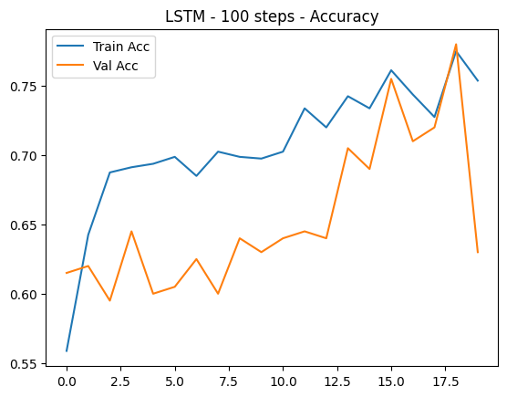

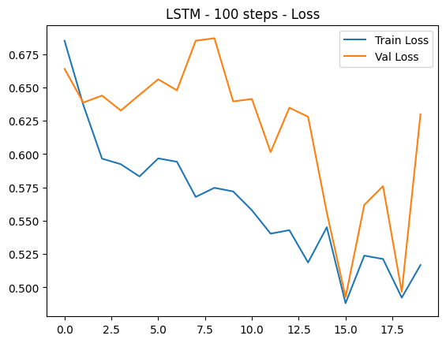

```
25/25 ━━━━━━━━━━━━━━━━━━━━ 6s 130ms/step - accuracy: 0.5294 - loss: 0.6904 - val_accuracy: 0.5500 - val_loss: 0.6852
25/25 ━━━━━━━━━━━━━━━━━━━━ 4s 99ms/step - accuracy: 0.6025 - loss: 0.6798 - val_accuracy: 0.6150 - val_loss: 0.6560
25/25 ━━━━━━━━━━━━━━━━━━━━ 3s 100ms/step - accuracy: 0.6342 - loss: 0.6483 - val_accuracy: 0.5600 - val_loss: 0.6731
25/25 ━━━━━━━━━━━━━━━━━━━━ 3s 117ms/step - accuracy: 0.6392 - loss: 0.6409 - val_accuracy: 0.5750 - val_loss: 0.6604
25/25 ━━━━━━━━━━━━━━━━━━━━ 3s 131ms/step - accuracy: 0.6789 - loss: 0.6116 - val_accuracy: 0.6650 - val_loss: 0.6175
25/25 ━━━━━━━━━━━━━━━━━━━━ 2s 96ms/step - accuracy: 0.6619 - loss: 0.6147 - val_accuracy: 0.6400 - val_loss: 0.6319
25/25 ━━━━━━━━━━━━━━━━━━━━ 3s 101ms/step - accuracy: 0.6855 - loss: 0.5986 - val_accuracy: 0.6700 - val_loss: 0.6145
25/25 ━━━━━━━━━━━━━━━━━━━━ 2s 96ms/step - accuracy: 0.7276 - loss: 0.5681 - val_accuracy: 0.6500 - val_loss: 0.6241
25/25 ━━━━━━━━━━━━━━━━━━━━ 3s 118ms/step - accuracy: 0.7202 - loss: 0.5666 - val_accuracy: 0.6150 - val_loss: 0.6413
25/25 ━━━━━━━━━━━━━━━━━━━━ 5s 99ms/step - accuracy: 0.7181 - loss: 0.5660 - val_accuracy: 0.6600 - val_loss: 0.6264
25/25 ━━━━━━━━━━━━━━━━━━━━ 2s 96ms/step - accuracy: 0.7271 - loss: 0.5784 - val_accuracy: 0.6350 - val_loss: 0.6362
25/25 ━━━━━━━━━━━━━━━━━━━━ 2s 98ms/step - accuracy: 0.7129 - loss: 0.5601 - val_accuracy: 0.6150 - val_loss: 0.6509
25/25 ━━━━━━━━━━━━━━━━━━━━ 3s 117ms/step - accuracy: 0.7222 - loss: 0.5672 - val_accuracy: 0.6150 - val_loss: 0.6717
25/25 ━━━━━━━━━━━━━━━━━━━━ 5s 101ms/step - accuracy: 0.7056 - loss: 0.5531 - val_accuracy: 0.6300 - val_loss: 0.6535
25/25 ━━━━━━━━━━━━━━━━━━━━ 3s 101ms/step - accuracy: 0.7376 - loss: 0.5404 - val_accuracy: 0.6050 - val_loss: 0.6550
25/25 ━━━━━━━━━━━━━━━━━━━━ 3s 100ms/step - accuracy: 0.7136 - loss: 0.5645 - val_accuracy: 0.5850 - val_loss: 0.6851
25/25 ━━━━━━━━━━━━━━━━━━━━ 3s 108ms/step - accuracy: 0.7207 - loss: 0.5636 - val_accuracy: 0.5750 - val_loss: 0.6863
25/25 ━━━━━━━━━━━━━━━━━━━━ 5s 97ms/step - accuracy: 0.7407 - loss: 0.5559 - val_accuracy: 0.6450 - val_loss: 0.6538
25/25 ━━━━━━━━━━━━━━━━━━━━ 3s 99ms/step - accuracy: 0.7297 - loss: 0.5428 - val_accuracy: 0.6500 - val_loss: 0.6415
25/25 ━━━━━━━━━━━━━━━━━━━━ 3s 101ms/step - accuracy: 0.7222 - loss: 0.5616 - val_accuracy: 0.6600 - val_loss: 0.6446
```

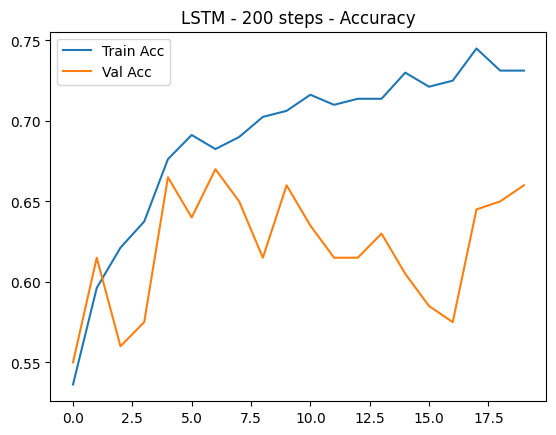

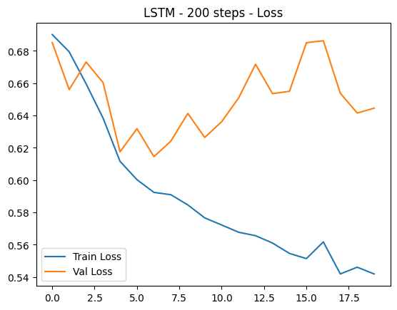

```
25/25 ━━━━━━━━━━━━━━━━━━━━ 7s 205ms/step - accuracy: 0.5386 - loss: 0.6923 - val_accuracy: 0.5300 - val_loss: 0.6905
25/25 ━━━━━━━━━━━━━━━━━━━━ 9s 154ms/step - accuracy: 0.5801 - loss: 0.6654 - val_accuracy: 0.6350 - val_loss: 0.6589
25/25 ━━━━━━━━━━━━━━━━━━━━ 5s 184ms/step - accuracy: 0.6222 - loss: 0.6596 - val_accuracy: 0.5650 - val_loss: 0.6937
25/25 ━━━━━━━━━━━━━━━━━━━━ 4s 139ms/step - accuracy: 0.5837 - loss: 0.6749 - val_accuracy: 0.5800 - val_loss: 0.6918
25/25 ━━━━━━━━━━━━━━━━━━━━ 6s 156ms/step - accuracy: 0.5378 - loss: 0.6787 - val_accuracy: 0.6000 - val_loss: 0.6880
25/25 ━━━━━━━━━━━━━━━━━━━━ 5s 200ms/step - accuracy: 0.6033 - loss: 0.6601 - val_accuracy: 0.6150 - val_loss: 0.6719
25/25 ━━━━━━━━━━━━━━━━━━━━ 4s 140ms/step - accuracy: 0.6326 - loss: 0.6471 - val_accuracy: 0.6500 - val_loss: 0.6220
25/25 ━━━━━━━━━━━━━━━━━━━━ 3s 139ms/step - accuracy: 0.6578 - loss: 0.6298 - val_accuracy: 0.6600 - val_loss: 0.6243
25/25 ━━━━━━━━━━━━━━━━━━━━ 4s 168ms/step - accuracy: 0.6524 - loss: 0.6290 - val_accuracy: 0.5600 - val_loss: 0.6833
25/25 ━━━━━━━━━━━━━━━━━━━━ 4s 166ms/step - accuracy: 0.6014 - loss: 0.6497 - val_accuracy: 0.6100 - val_loss: 0.6717
25/25 ━━━━━━━━━━━━━━━━━━━━ 4s 140ms/step - accuracy: 0.6325 - loss: 0.6381 - val_accuracy: 0.6750 - val_loss: 0.6215
25/25 ━━━━━━━━━━━━━━━━━━━━ 4s 155ms/step - accuracy: 0.6951 - loss: 0.6107 - val_accuracy: 0.6750 - val_loss: 0.6124
25/25 ━━━━━━━━━━━━━━━━━━━━ 5s 158ms/step - accuracy: 0.6734 - loss: 0.5804 - val_accuracy: 0.6900 - val_loss: 0.6235
25/25 ━━━━━━━━━━━━━━━━━━━━ 5s 141ms/step - accuracy: 0.7087 - loss: 0.5839 - val_accuracy: 0.6650 - val_loss: 0.6282
25/25 ━━━━━━━━━━━━━━━━━━━━ 4s 152ms/step - accuracy: 0.6668 - loss: 0.6088 - val_accuracy: 0.6700 - val_loss: 0.5916
25/25 ━━━━━━━━━━━━━━━━━━━━ 5s 153ms/step - accuracy: 0.6949 - loss: 0.5890 - val_accuracy: 0.6950 - val_loss: 0.6039
25/25 ━━━━━━━━━━━━━━━━━━━━ 5s 140ms/step - accuracy: 0.6990 - loss: 0.5834 - val_accuracy: 0.7100 - val_loss: 0.6049
25/25 ━━━━━━━━━━━━━━━━━━━━ 4s 157ms/step - accuracy: 0.7238 - loss: 0.5676 - val_accuracy: 0.7100 - val_loss: 0.6144
25/25 ━━━━━━━━━━━━━━━━━━━━ 4s 174ms/step - accuracy: 0.7050 - loss: 0.5788 - val_accuracy: 0.6950 - val_loss: 0.6099
25/25 ━━━━━━━━━━━━━━━━━━━━ 4s 141ms/step - accuracy: 0.7368 - loss: 0.5470 - val_accuracy: 0.6950 - val_loss: 0.6169
```

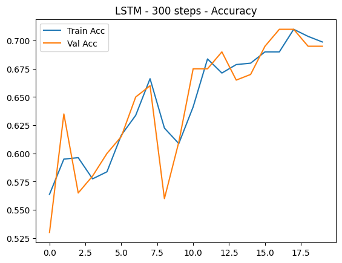

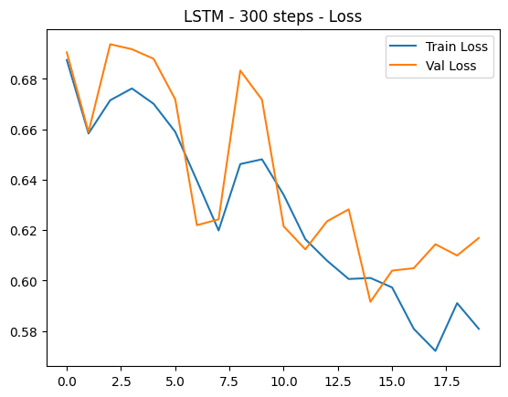

```
13/13 ━━━━━━━━━━━━━━━━━━━━ 6s 125ms/step - accuracy: 0.5437 - loss: 0.6808 - val_accuracy: 0.6300 - val_loss: 0.6661
13/13 ━━━━━━━━━━━━━━━━━━━━ 2s 76ms/step - accuracy: 0.5634 - loss: 0.6767 - val_accuracy: 0.6350 - val_loss: 0.6681
13/13 ━━━━━━━━━━━━━━━━━━━━ 1s 52ms/step - accuracy: 0.6258 - loss: 0.6717 - val_accuracy: 0.6250 - val_loss: 0.6660
13/13 ━━━━━━━━━━━━━━━━━━━━ 1s 53ms/step - accuracy: 0.6375 - loss: 0.6684 - val_accuracy: 0.6400 - val_loss: 0.6649
13/13 ━━━━━━━━━━━━━━━━━━━━ 1s 51ms/step - accuracy: 0.6251 - loss: 0.6662 - val_accuracy: 0.6600 - val_loss: 0.6609
13/13 ━━━━━━━━━━━━━━━━━━━━ 1s 52ms/step - accuracy: 0.6209 - loss: 0.6678 - val_accuracy: 0.6600 - val_loss: 0.6636
13/13 ━━━━━━━━━━━━━━━━━━━━ 1s 51ms/step - accuracy: 0.6070 - loss: 0.6653 - val_accuracy: 0.6600 - val_loss: 0.6605
13/13 ━━━━━━━━━━━━━━━━━━━━ 1s 52ms/step - accuracy: 0.6419 - loss: 0.6564 - val_accuracy: 0.6650 - val_loss: 0.6581
13/13 ━━━━━━━━━━━━━━━━━━━━ 1s 50ms/step - accuracy: 0.6314 - loss: 0.6571 - val_accuracy: 0.6650 - val_loss: 0.6578
13/13 ━━━━━━━━━━━━━━━━━━━━ 1s 51ms/step - accuracy: 0.6591 - loss: 0.6561 - val_accuracy: 0.6850 - val_loss: 0.6544
13/13 ━━━━━━━━━━━━━━━━━━━━ 1s 52ms/step - accuracy: 0.6242 - loss: 0.6545 - val_accuracy: 0.6500 - val_loss: 0.6543
13/13 ━━━━━━━━━━━━━━━━━━━━ 1s 52ms/step - accuracy: 0.6614 - loss: 0.6456 - val_accuracy: 0.6450 - val_loss: 0.6521
13/13 ━━━━━━━━━━━━━━━━━━━━ 1s 52ms/step - accuracy: 0.6722 - loss: 0.6467 - val_accuracy: 0.6150 - val_loss: 0.6516
13/13 ━━━━━━━━━━━━━━━━━━━━ 1s 50ms/step - accuracy: 0.6551 - loss: 0.6415 - val_accuracy: 0.6150 - val_loss: 0.6500
13/13 ━━━━━━━━━━━━━━━━━━━━ 1s 81ms/step - accuracy: 0.6800 - loss: 0.6372 - val_accuracy: 0.6050 - val_loss: 0.6492
13/13 ━━━━━━━━━━━━━━━━━━━━ 1s 84ms/step - accuracy: 0.6689 - loss: 0.6330 - val_accuracy: 0.6200 - val_loss: 0.6451
13/13 ━━━━━━━━━━━━━━━━━━━━ 1s 88ms/step - accuracy: 0.6646 - loss: 0.6262 - val_accuracy: 0.5750 - val_loss: 0.6481
13/13 ━━━━━━━━━━━━━━━━━━━━ 1s 70ms/step - accuracy: 0.6439 - loss: 0.6325 - val_accuracy: 0.5900 - val_loss: 0.6463
13/13 ━━━━━━━━━━━━━━━━━━━━ 1s 52ms/step - accuracy: 0.6718 - loss: 0.6147 - val_accuracy: 0.6100 - val_loss: 0.6420
13/13 ━━━━━━━━━━━━━━━━━━━━ 1s 59ms/step - accuracy: 0.6574 - loss: 0.6193 - val_accuracy: 0.5950 - val_loss: 0.6429
```

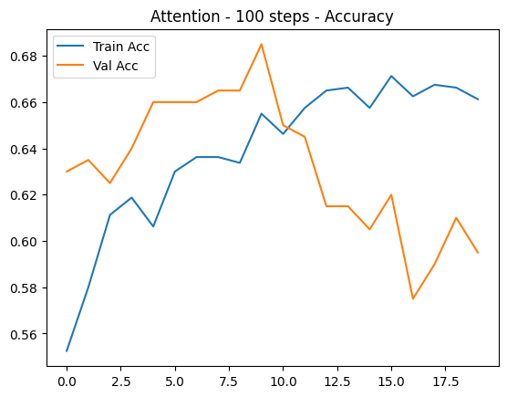

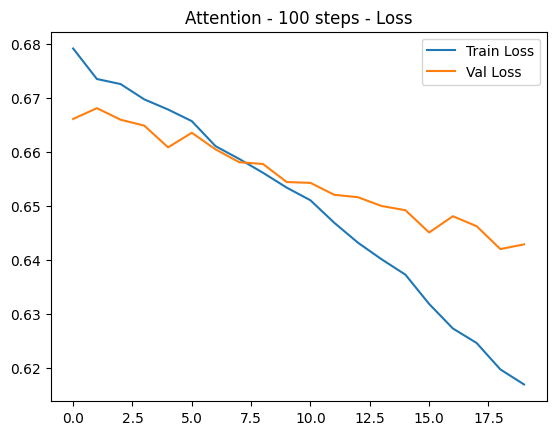

```
13/13 ━━━━━━━━━━━━━━━━━━━━ 6s 154ms/step - accuracy: 0.4818 - loss: 0.6987 - val_accuracy: 0.5450 - val_loss: 0.6840
13/13 ━━━━━━━━━━━━━━━━━━━━ 3s 155ms/step - accuracy: 0.5756 - loss: 0.6846 - val_accuracy: 0.6100 - val_loss: 0.6714
13/13 ━━━━━━━━━━━━━━━━━━━━ 3s 210ms/step - accuracy: 0.5681 - loss: 0.6795 - val_accuracy: 0.5850 - val_loss: 0.6681
13/13 ━━━━━━━━━━━━━━━━━━━━ 2s 156ms/step - accuracy: 0.5589 - loss: 0.6804 - val_accuracy: 0.6100 - val_loss: 0.6680
13/13 ━━━━━━━━━━━━━━━━━━━━ 2s 138ms/step - accuracy: 0.5571 - loss: 0.6840 - val_accuracy: 0.6450 - val_loss: 0.6685
13/13 ━━━━━━━━━━━━━━━━━━━━ 2s 130ms/step - accuracy: 0.5599 - loss: 0.6825 - val_accuracy: 0.6300 - val_loss: 0.6658
13/13 ━━━━━━━━━━━━━━━━━━━━ 2s 141ms/step - accuracy: 0.5866 - loss: 0.6785 - val_accuracy: 0.6200 - val_loss: 0.6629
13/13 ━━━━━━━━━━━━━━━━━━━━ 2s 126ms/step - accuracy: 0.5866 - loss: 0.6699 - val_accuracy: 0.6200 - val_loss: 0.6604
13/13 ━━━━━━━━━━━━━━━━━━━━ 2s 186ms/step - accuracy: 0.5826 - loss: 0.6730 - val_accuracy: 0.6400 - val_loss: 0.6595
13/13 ━━━━━━━━━━━━━━━━━━━━ 3s 199ms/step - accuracy: 0.5919 - loss: 0.6731 - val_accuracy: 0.6450 - val_loss: 0.6569
13/13 ━━━━━━━━━━━━━━━━━━━━ 4s 138ms/step - accuracy: 0.6064 - loss: 0.6663 - val_accuracy: 0.6700 - val_loss: 0.6552
13/13 ━━━━━━━━━━━━━━━━━━━━ 2s 126ms/step - accuracy: 0.6254 - loss: 0.6629 - val_accuracy: 0.6450 - val_loss: 0.6495
13/13 ━━━━━━━━━━━━━━━━━━━━ 3s 139ms/step - accuracy: 0.6188 - loss: 0.6597 - val_accuracy: 0.6550 - val_loss: 0.6470
13/13 ━━━━━━━━━━━━━━━━━━━━ 3s 211ms/step - accuracy: 0.6365 - loss: 0.6553 - val_accuracy: 0.6850 - val_loss: 0.6448
13/13 ━━━━━━━━━━━━━━━━━━━━ 2s 165ms/step - accuracy: 0.6311 - loss: 0.6547 - val_accuracy: 0.6900 - val_loss: 0.6407
13/13 ━━━━━━━━━━━━━━━━━━━━ 2s 129ms/step - accuracy: 0.6350 - loss: 0.6465 - val_accuracy: 0.6850 - val_loss: 0.6347
13/13 ━━━━━━━━━━━━━━━━━━━━ 3s 138ms/step - accuracy: 0.6409 - loss: 0.6433 - val_accuracy: 0.7100 - val_loss: 0.6343
13/13 ━━━━━━━━━━━━━━━━━━━━ 2s 127ms/step - accuracy: 0.6462 - loss: 0.6388 - val_accuracy: 0.6950 - val_loss: 0.6278
13/13 ━━━━━━━━━━━━━━━━━━━━ 2s 127ms/step - accuracy: 0.6411 - loss: 0.6364 - val_accuracy: 0.6800 - val_loss: 0.6228
13/13 ━━━━━━━━━━━━━━━━━━━━ 4s 203ms/step - accuracy: 0.6567 - loss: 0.6254 - val_accuracy: 0.6900 - val_loss: 0.6192
```

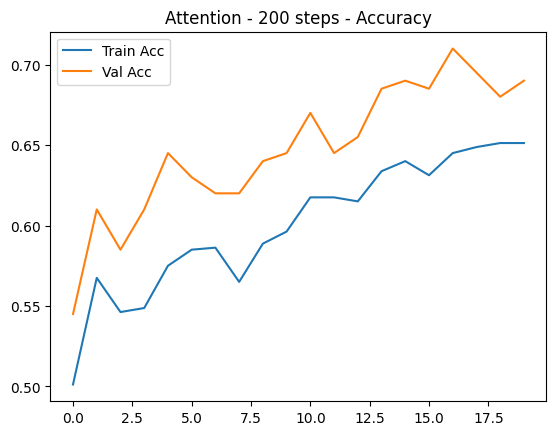

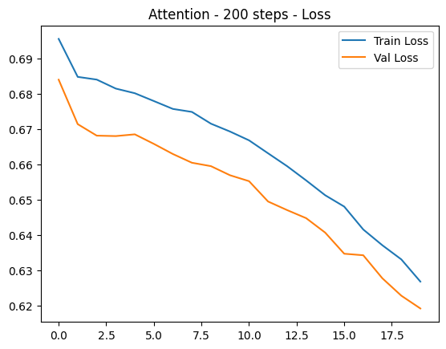

```
13/13 ━━━━━━━━━━━━━━━━━━━━ 8s 348ms/step - accuracy: 0.4376 - loss: 0.7433 - val_accuracy: 0.4750 - val_loss: 0.6943
13/13 ━━━━━━━━━━━━━━━━━━━━ 5s 363ms/step - accuracy: 0.4858 - loss: 0.6950 - val_accuracy: 0.5950 - val_loss: 0.6782
13/13 ━━━━━━━━━━━━━━━━━━━━ 4s 271ms/step - accuracy: 0.5806 - loss: 0.6789 - val_accuracy: 0.5400 - val_loss: 0.6770
13/13 ━━━━━━━━━━━━━━━━━━━━ 5s 279ms/step - accuracy: 0.5690 - loss: 0.6719 - val_accuracy: 0.5400 - val_loss: 0.6770
13/13 ━━━━━━━━━━━━━━━━━━━━ 5s 294ms/step - accuracy: 0.5691 - loss: 0.6698 - val_accuracy: 0.5450 - val_loss: 0.6746
13/13 ━━━━━━━━━━━━━━━━━━━━ 4s 277ms/step - accuracy: 0.5521 - loss: 0.6719 - val_accuracy: 0.5450 - val_loss: 0.6727
13/13 ━━━━━━━━━━━━━━━━━━━━ 3s 255ms/step - accuracy: 0.5783 - loss: 0.6710 - val_accuracy: 0.5450 - val_loss: 0.6711
13/13 ━━━━━━━━━━━━━━━━━━━━ 5s 419ms/step - accuracy: 0.5715 - loss: 0.6693 - val_accuracy: 0.5800 - val_loss: 0.6690
13/13 ━━━━━━━━━━━━━━━━━━━━ 8s 250ms/step - accuracy: 0.5616 - loss: 0.6723 - val_accuracy: 0.5950 - val_loss: 0.6666
13/13 ━━━━━━━━━━━━━━━━━━━━ 6s 333ms/step - accuracy: 0.5714 - loss: 0.6703 - val_accuracy: 0.5900 - val_loss: 0.6648
13/13 ━━━━━━━━━━━━━━━━━━━━ 3s 251ms/step - accuracy: 0.5960 - loss: 0.6595 - val_accuracy: 0.5750 - val_loss: 0.6635
13/13 ━━━━━━━━━━━━━━━━━━━━ 5s 254ms/step - accuracy: 0.5708 - loss: 0.6651 - val_accuracy: 0.6100 - val_loss: 0.6596
13/13 ━━━━━━━━━━━━━━━━━━━━ 6s 288ms/step - accuracy: 0.5928 - loss: 0.6681 - val_accuracy: 0.6050 - val_loss: 0.6565
13/13 ━━━━━━━━━━━━━━━━━━━━ 3s 249ms/step - accuracy: 0.5888 - loss: 0.6652 - val_accuracy: 0.6100 - val_loss: 0.6544
13/13 ━━━━━━━━━━━━━━━━━━━━ 6s 297ms/step - accuracy: 0.6055 - loss: 0.6491 - val_accuracy: 0.6150 - val_loss: 0.6518
13/13 ━━━━━━━━━━━━━━━━━━━━ 5s 350ms/step - accuracy: 0.6189 - loss: 0.6452 - val_accuracy: 0.6300 - val_loss: 0.6463
13/13 ━━━━━━━━━━━━━━━━━━━━ 4s 276ms/step - accuracy: 0.6502 - loss: 0.6485 - val_accuracy: 0.6650 - val_loss: 0.6416
13/13 ━━━━━━━━━━━━━━━━━━━━ 6s 326ms/step - accuracy: 0.6667 - loss: 0.6406 - val_accuracy: 0.6350 - val_loss: 0.6389
13/13 ━━━━━━━━━━━━━━━━━━━━ 5s 346ms/step - accuracy: 0.6456 - loss: 0.6415 - val_accuracy: 0.6550 - val_loss: 0.6337
13/13 ━━━━━━━━━━━━━━━━━━━━ 4s 252ms/step - accuracy: 0.6842 - loss: 0.6267 - val_accuracy: 0.6850 - val_loss: 0.6281
```

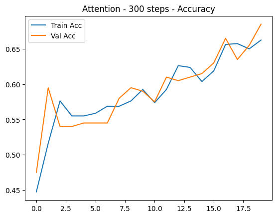

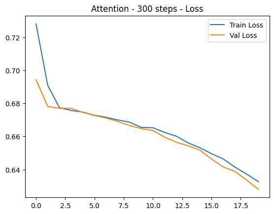

```python
# retraining model on each dataset
def train_todata(x_train, y_train, x_test, y_test, model_builder, params, model_type):
    model_build_params = {k: v for k, v in params.items() if k != 'batch_size'}
    sequence_length = x_train.shape[1]
    feature_dim = x_train.shape[2]
    model = model_builder(
        **model_build_params,
        sequence_length=sequence_length,
        feature_dim=feature_dim
        )

    history = model.fit(
        x_train, y_train,
        validation_data=(x_test, y_test),
        epochs=20,
        batch_size=params['batch_size']
        )
    plot_training(history, f"{model_type} - {x_train.shape[1]} steps")
    return history.history['val_accuracy'][-1]

lstm_val_acc_100 = train_todata(x_train_100, y_train_100, x_test_100, y_test_100, lstm_model, best_lstm_parameters,"LSTM")
lstm_val_acc_200 = train_todata(x_train_200, y_train_200, x_test_200, y_test_200, lstm_model, best_lstm_parameters,"LSTM")
lstm_val_acc_300 = train_todata(x_train_300, y_train_300, x_test_300, y_test_300, lstm_model, best_lstm_parameters,"LSTM")

attn_val_acc_100 = train_todata(x_train_100, y_train_100, x_test_100, y_test_100, attention_model, best_attn_parameters,"Attention")
attn_val_acc_200 = train_todata(x_train_200, y_train_200, x_test_200, y_test_200, attention_model, best_attn_parameters,"Attention")
attn_val_acc_300 = train_todata(x_train_300, y_train_300, x_test_300, y_test_300, attention_model, best_attn_parameters,"Attention")
```

# Q5: Analysis and Discussion [1 pts]

● Analyze how varying the sequence length (100, 200, and 300 time steps) affects the performance of your models.  
● Compare the performance of the LSTM and Attention-based models, and determine which model performs better on longer sequences. Discuss potential reasons for your observations, considering the differences in how each architecture processes temporal information.

```python
#!pip install
#!jupyter nbconvert --to html "/content/drive/MyDrive/QBIO465/SEB QBIO465 HW8.ipynb"
```